# Reproducible Research: Part 1

Ribery

9 октомври 2015 г.

Part 1

1. Load the data (i.e. read.csv())

```
##   steps       date interval
## 1    NA 2012-10-01        0
## 2    NA 2012-10-01        5
## 3    NA 2012-10-01       10
## 4    NA 2012-10-01       15
## 5    NA 2012-10-01       20
## 6    NA 2012-10-01       25
```

What is the mean total number of steps taken per day? For this part of the assignment, you can ignore the missing values in the dataset.

Make a histogram of the total number of steps taken each day

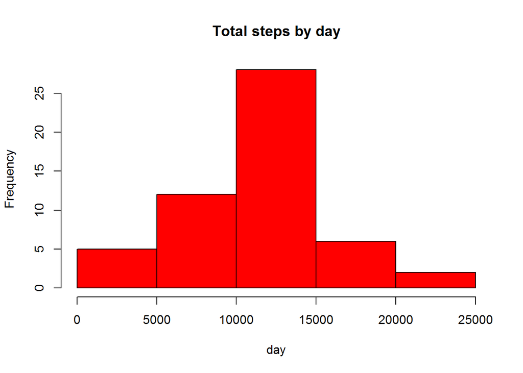

And the mean and median and mean is

```
## [1] 10765
```

```
## [1] 10766.19
```

The second approach is to make a data frame first with the values that I need I create a data frame with the days and the total of steps by day.

```
## [1] 61
```

Then the data frame is

```
##          day steps
## 1 2012-10-01     0
## 2 2012-10-02   126
## 3 2012-10-03 11352
## 4 2012-10-04 12116
## 5 2012-10-05 13294
## 6 2012-10-06 15420
```

Now i make the histogram

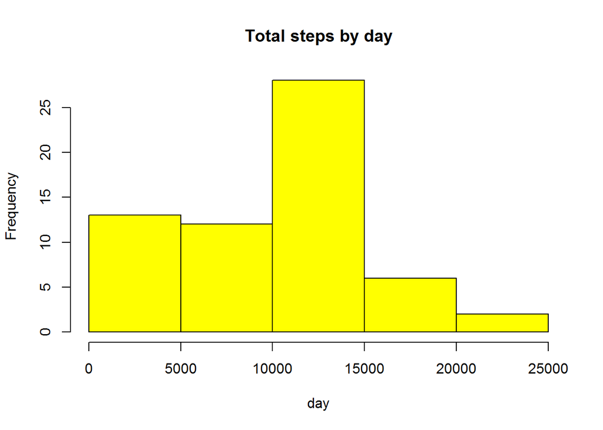

What is the average daily activity pattern?

Make a time series plot (i.e. type = “l”) of the 5-minute interval (x-axis) and the average number of steps taken, averaged across all days (y-axis)

Now I get mean of steps and time series plot

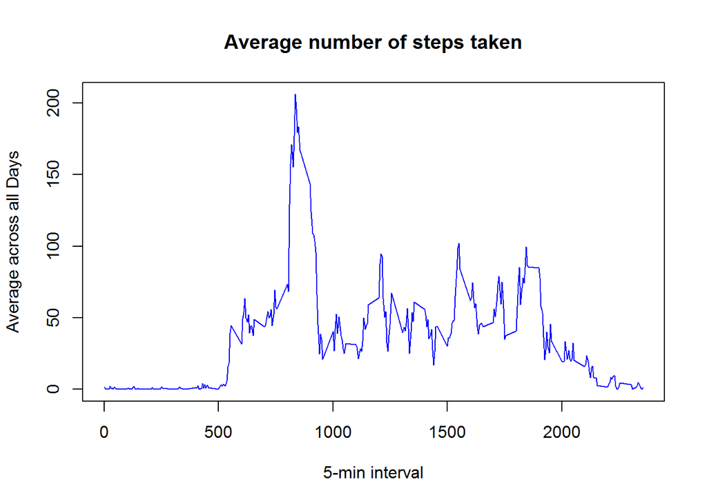

Which 5-minute interval, on average across all the days in the dataset, contains the maximum number of steps?

```
## [1] "835"
```

Imputing missing values

Calculate and report the total number of missing values in the dataset (i.e. the total number of rows with NAs)

```
## [1] 2304
```

Devise a strategy for filling in all of the missing values in the dataset. The strategy does not need to be sophisticated. For example, you could use the mean/median for that day, or the mean for that 5-minute interval,etc

Fist Na replaced by mean in 5 min interval

Create a new dataset that is equal to the original dataset but with the missing data filled in.

Make a histogram of the total number of steps taken each day and Calculate and report the mean and median total number of steps taken per day. Do these values differ from the estimates from the first part of the assignment? What is the impact of imputing missing data on the estimates of the total daily number of steps?

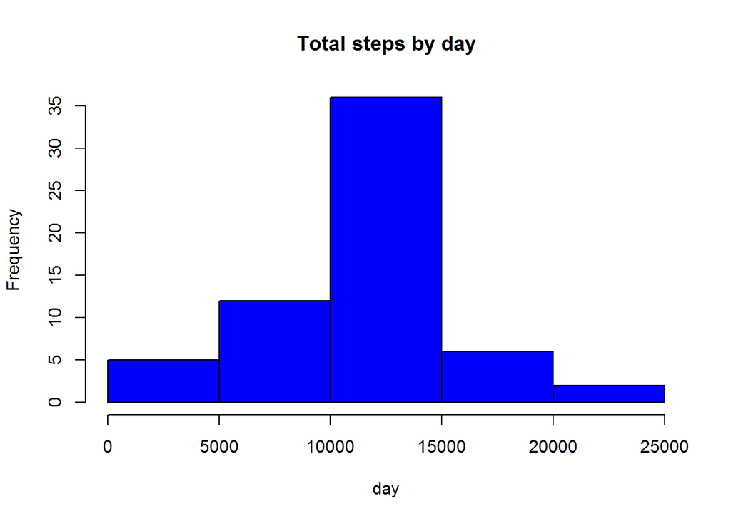

And the mean and median is

```
## [1] 10766.19
```

```
## [1] 10766.19
```

For this part the weekdays() function may be of some help here. Use the dataset with the filled-in missing values for this part.

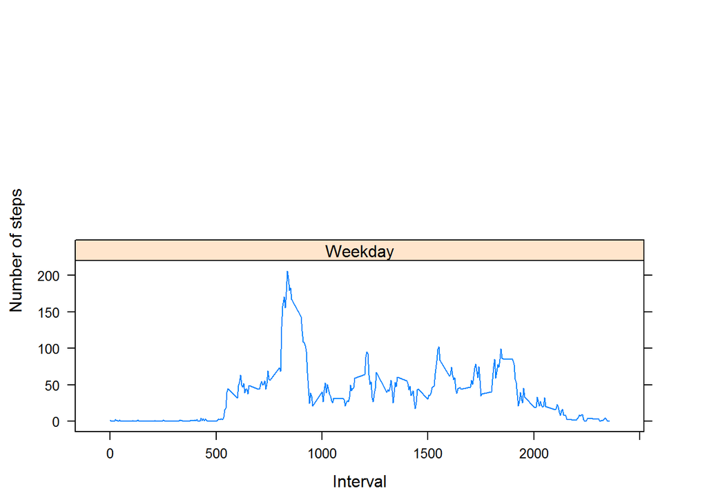